# Class 6: R Functions

Meisha Khan

1/24/2020

## This is a level 2 heading

This is **regular** old *text*!

### This is a level 3 heading

and a list of stuff

- thing one
- thing two
- and another thing

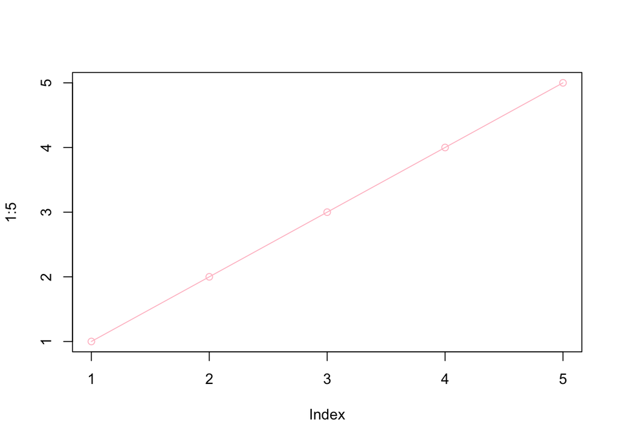

```r
plot(1:5, col="pink", type="o")
```

let’s insert a code chunk with the shortcut `Option-CMD-i`:

```r
x <- c(1:10)
x
```

```
##  [1]  1  2  3  4  5  6  7  8  9 10
```

here is my analysis of new data. it looks ok.. the mean of your data is 5.5.

## More on reading input files

We will use the read.table input must have “file” for read.table other common arguments: sep = " (tab), header = (TRUE/FALSE)

## TEST FILE 1

```r
x <- read.table("test1.txt", header = TRUE, sep = ",")
x
```

```
##   Col1 Col2 Col3
## 1    1    2    3
## 2    4    5    6
## 3    7    8    9
## 4    a    b    c
```

OR

```r
x <- read.csv("test1.txt")
x
```

```
##   Col1 Col2 Col3
## 1    1    2    3
## 2    4    5    6
## 3    7    8    9
## 4    a    b    c
```

## TEST FILE 2

```r
x2 <- read.table("test2.txt", header = TRUE, sep = "$")
x2
```

```
##   Col1 Col2 Col3
## 1    1    2    3
## 2    4    5    6
## 3    7    8    9
## 4    a    b    c
```

## TEST FILE 3

```r
x3 <- read.table("test3.txt")
x3
```

```
##   V1 V2 V3
## 1  1  6  a
## 2  2  7  b
## 3  3  8  c
## 4  4  9  d
## 5  5 10  e
```

## OUR FIRST FUNCTION

This is an example function named `add` with input `x` and `y`

```r
add <- function(x, y=1) {
 # Sum the input x and y
 x + y
}
```

Let’s try using it here…

```r
add(c(1,6,2), 4)
```

```
## [1]  5 10  6
```

OR

```r
add(x=c(1,6,2), y=4)
```

```
## [1]  5 10  6
```

same thing

other examples:

```r
add(x=1, y=4)
```

```
## [1] 5
```

```r
add(1, 4)
```

```
## [1] 5
```

```r
add(1)
```

```
## [1] 2
```

```r
add( c(1, 2, 3) )
```

```
## [1] 2 3 4
```

```r
add( c(1, 2, 3), 4 )
```

```
## [1] 5 6 7
```

### if you do a function more than 3 times, its time to **function**

Start with a working code snippet, simplify, reduce calculation duplication, and finally *turn it into a function!*

range function calculates min and max

```r
x <- c(10,4,22,6)
min(x)
```

```
## [1] 4
```

```r
max(x)
```

```
## [1] 22
```

```r
range(x)
```

```
## [1]  4 22
```

A 2nd example function to re-scale data to lie between 0 and 1

```r
rescale <- function(x) {
 rng <-range(x)
 (x - rng[1]) / (rng[2] - rng[1])
}
```

Let’s try using it here…

```r
rescale(1:10)
```

```
##  [1] 0.0000000 0.1111111 0.2222222 0.3333333 0.4444444 0.5555556 0.6666667
##  [8] 0.7777778 0.8888889 1.0000000
```

what happens if NA is used?

```r
rescale( c(1:10, NA))
```

```
##  [1] NA NA NA NA NA NA NA NA NA NA NA
```

we broke it - wmhy? well…

```r
x <- c(1:10, na.rm = FALSE)
 rng <-range(x)
 rng
```

```
## [1]  0 10
```

```r
x <- c(1:10, na.rm = TRUE)
 rng <-range(x)
 rng
```

```
## [1]  1 10
```

FIX FOR missing values NAs

```r
rescale2 <- function(x) {
 rng <-range(x, na.rm=TRUE)
 (x - rng[1]) / (rng[2] - rng[1])
}
```

```r
rescale2( c(1:10, NA))
```

```
##  [1] 0.0000000 0.1111111 0.2222222 0.3333333 0.4444444 0.5555556 0.6666667
##  [8] 0.7777778 0.8888889 1.0000000        NA
```

take piece of code, extract code, make it simpler, probably break it, figure whats broken, reiterate it, and then finally find function

```r
rescale3 <- function(x, na.rm=TRUE, plot=FALSE) {

 rng <-range(x, na.rm=na.rm)
 print("Hello")

 answer <- (x - rng[1]) / (rng[2] - rng[1])

 print("is it me you are looking for?")

 if(plot) {
   print("please don't sing to me")
 plot(answer, typ="b", lwd=4)
 }

 print("I can see it in ...")
 return(answer)

}
```

```
## [1] "Hello"
## [1] "is it me you are looking for?"
## [1] "please don't sing to me"
```

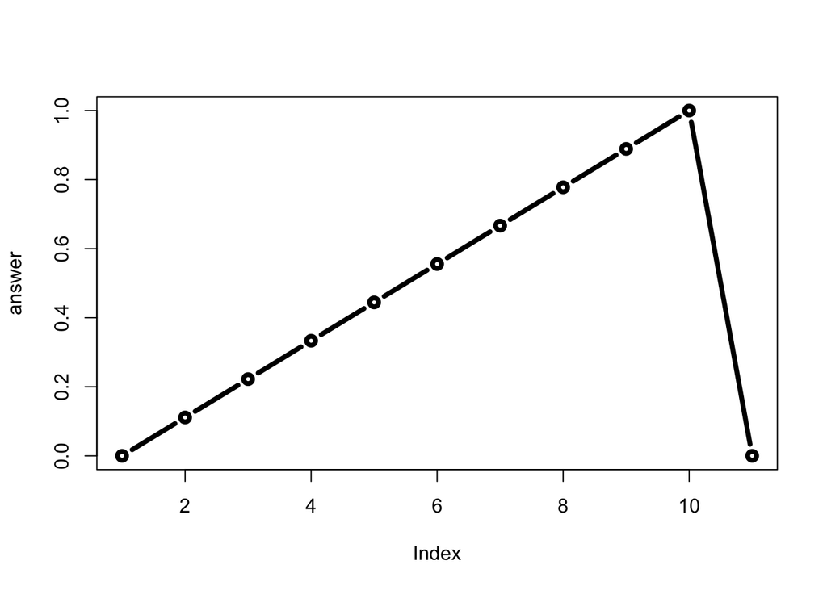

```
## [1] "I can see it in ..."
```

```
##
## 0.0000000 0.1111111 0.2222222 0.3333333 0.4444444 0.5555556 0.6666667 0.7777778
##                         na.rm
## 0.8888889 1.0000000 0.0000000
```

```r
rescale3(x, plot=TRUE)
```